# Bayesian Motivation

Logan Harris

2023-08-17

To do: - get plots similar to those on coverage page but for updated bootstrap method

Idea pulled from derivation here: http://www.math.chalmers.se/Stat/Grundutb/GU/MSA220/S18/bayeslasso.pdf

Steps in interval construction:

1. Run lasso with cross validation
2. Use cv results to select lambda, coef estimates at that lambda, and determine sd estimate
3. The full conditional for $\frac{1}{\tau_j^2}$ is inverse Gaussian with:

$$\begin{aligned}
\mu^* = \sqrt{\frac{\lambda^2 \sigma^2}{\beta_j^2}}, \lambda^* =
\lambda^2
\end{aligned}$$

So, for every $\beta_j$, marginally, compute these values and then draw randomly from this inverse gaussian.

4. With this value, for each $\beta$ we are going to then do a number of steps, noting that the $\boldsymbol{\beta}$s are multivariate normal with:

$$\boldsymbol{\mu} =
\boldsymbol{A}^{-1}\boldsymbol{X}^T\tilde{\boldsymbol{y}}, \sigma^2 =
\sigma^2 \boldsymbol{A}^{-1}, \text{ and } \boldsymbol{A} =
\boldsymbol{X}^{T}\boldsymbol{X} + \boldsymbol{D}^{-1}_{\tau} \text{ and
} \boldsymbol{D}_{\tau} = diag(\tau^2_j)$$

However, we again are going to treat each marginally, and get an estimate of $\sigma^2$ using the se estimate from CV and our estimate for $\tau^2_j$ by taking the inverse of the respective draw from step 3.

1. Compute the partial residual (use this for $\tilde{\boldsymbol{y}}$)
2. Compute $\boldsymbol{A}$
3. Use these components to get a marginal normal distribution for parameter j
4. Compute the interval of interest
5. Repeat N times
6. Take the means of the lower and upper bounds of intervals as the final interval estimate

Interval widths are set to be 80%.

# One Covariate

## Beta = 0

### Single Example

```r
beta0 <- eb_boot(beta = 0, p = 1, b = 0, n = 30, niter = 100)
c(mean(beta0$lower), mean(beta0$upper))
```

```
## [1] -0.6757532 -0.1797490
```

### Coverage

```r
set.seed(1234)
res <- eb_boot_sim(beta = 0, p = 1, b = 0, n = 30, niter = 100, nboot = 100); save(res, file = "beta0_cov.rds")
mean(res$overall_cov)
```

```
## [1] 0.83
```

## Beta = 3

```r
beta0 <- eb_boot(beta = 3, p = 1, b = 0, n = 30, niter = 100)
c(mean(beta0$lower), mean(beta0$upper))
```

```
## [1] 2.991019 3.377055
```

```r
set.seed(1234)
res <- eb_boot_sim(beta = 3, p = 1, b = 0, n = 30, niter = 100, nboot = 100); save(res, file = "beta3_cov.rds")
mean(res$overall_cov)
```

```
## [1] 0.82
```

# Many Covariates

## Not High Dimensional

### Single Example

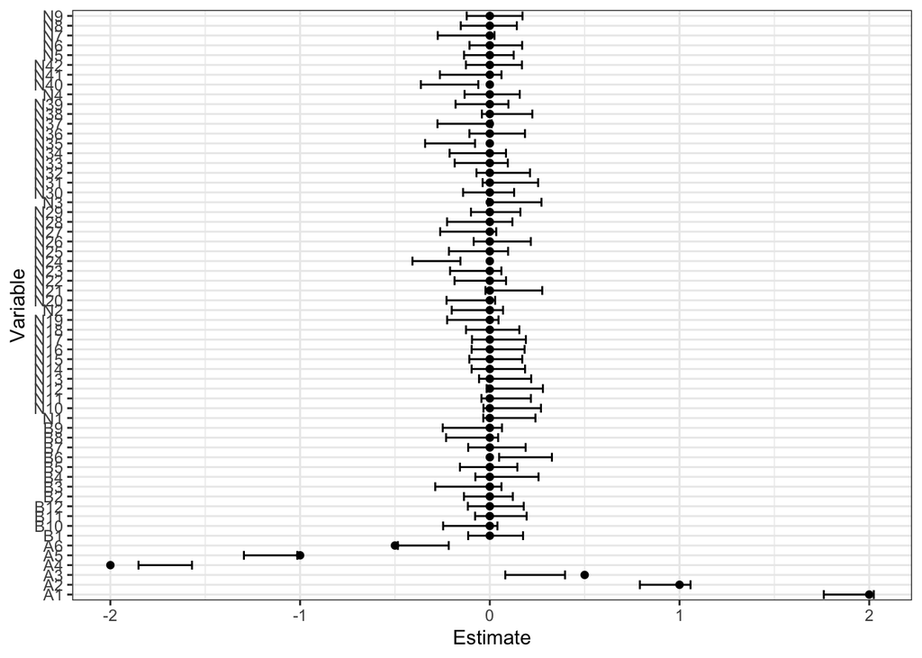

```r
tmp <- eb_boot(beta = c(2, 1, 0.5, -2, -1, -0.5))
plot_boot(tmp)
```

### Coverage

```r
set.seed(123)
res <- eb_boot_sim(beta = c(2, 1, 0.5, -2, -1, -0.5))
save(res, file = "many.rds")
```

#### Overall Coverage (per bootstrap)

```r
mean(res$overall_cov)
```

```
## [1] 0.798
```

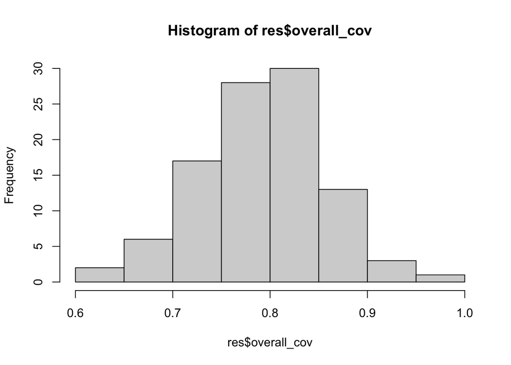

```r
hist(res$overall_cov)
```

#### Individual Coverage (per covariate)

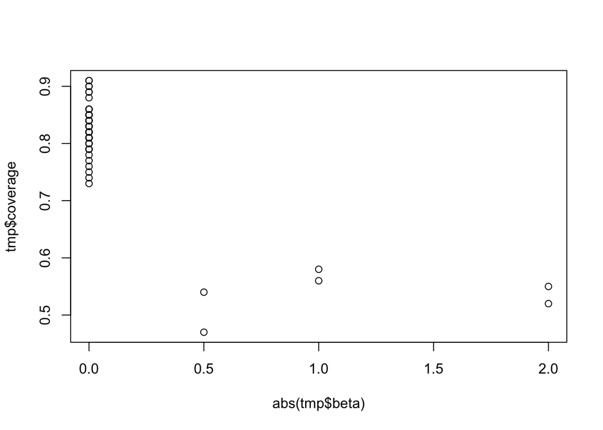

```r
tmp <- data.frame(coverage = apply(res$indiv_cov, 2, mean) , beta = res$truth)
plot(abs(tmp$beta), tmp$coverage)
```

## n = p

Here, I simply increase the number of true zeros. What I was interested in seeing was: 1) does the increase in sparsity effect the coverage of the non-zero coefficients, 2) Does it impact the marginal coverage rate?

### Single Example

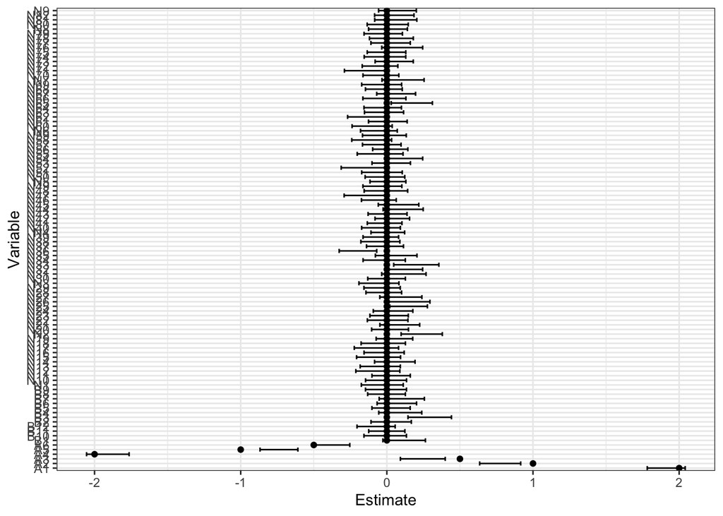

```r
tmp <- eb_boot(beta = c(2, 1, 0.5, -2, -1, -0.5), p = 100)
plot_boot(tmp)
```

### Coverage

```r
set.seed(123)
res <- eb_boot_sim(beta = c(2, 1, 0.5, -2, -1, -0.5), p = 100)
save(res, file = "nep.rds")
```

#### Overall Coverage (per bootstrap)

```r
mean(res$overall_cov)
```

```
## [1] 0.8776
```

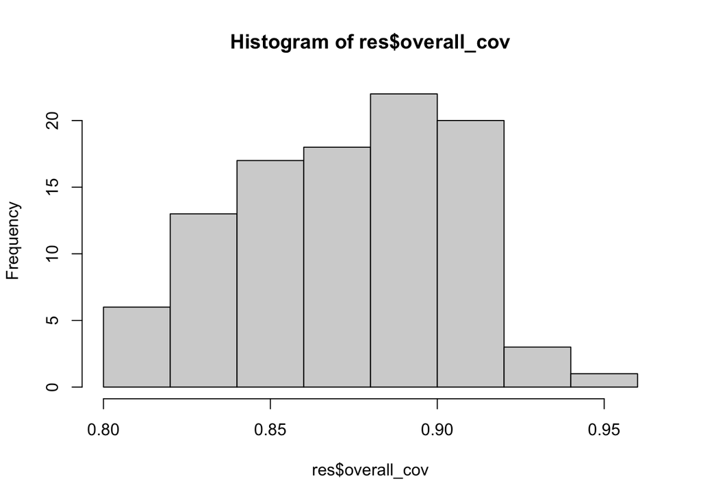

```r
hist(res$overall_cov)
```

#### Individual Coverage (per covariate)

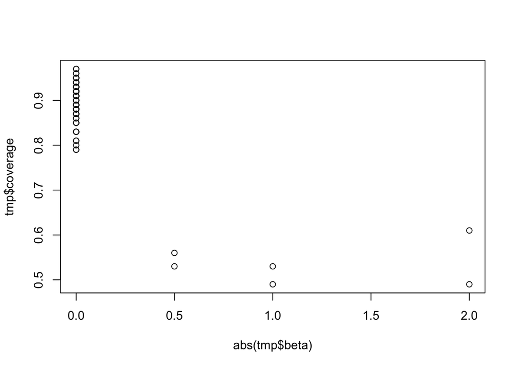

```r
tmp <- data.frame(coverage = apply(res$indiv_cov, 2, mean) , beta = res$truth)
plot(abs(tmp$beta), tmp$coverage)
```

## Increating betas, Not High Dimensional

### Single Example

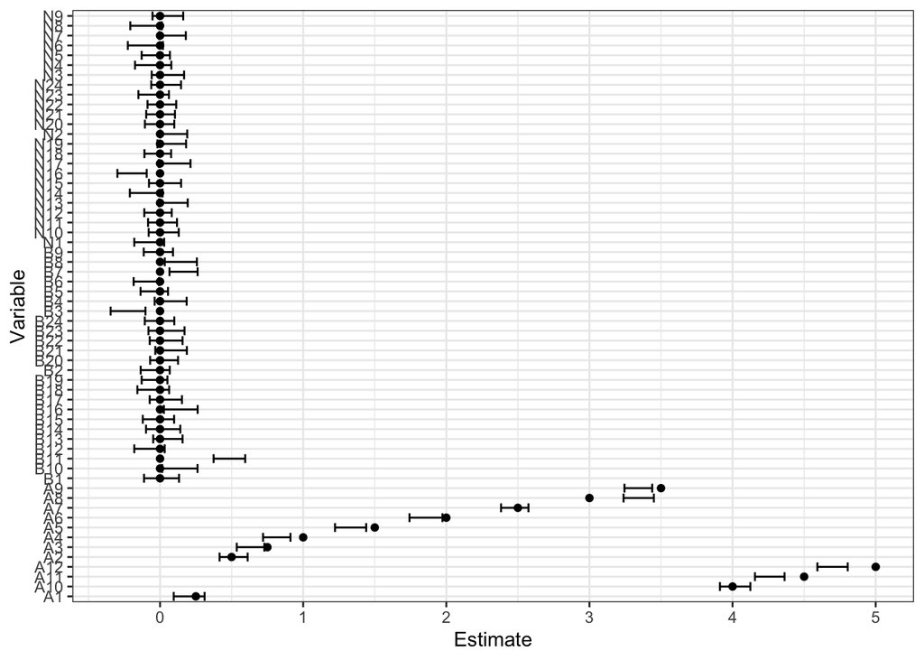

```r
tmp <- eb_boot(beta = c(0.25, 0.5, 0.75, 1, 1.5, 2, 2.5, 3, 3.5, 4, 4.5, 5))
plot_boot(tmp)
```

### Coverage

```r
set.seed(123)
res <- eb_boot_sim(beta = c(0.25, 0.5, 0.75, 1, 1.5, 2, 2.5, 3, 3.5, 4, 4.5, 5))
save(res, file = "increasing.rds")
```

#### Overall Coverage (per bootstrap)

```r
mean(res$overall_cov)
```

```
## [1] 0.7755
```

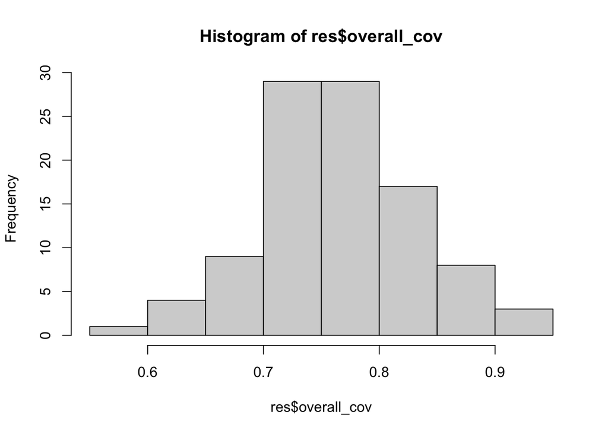

```r
hist(res$overall_cov)
```

#### Individual Coverage (per covariate)

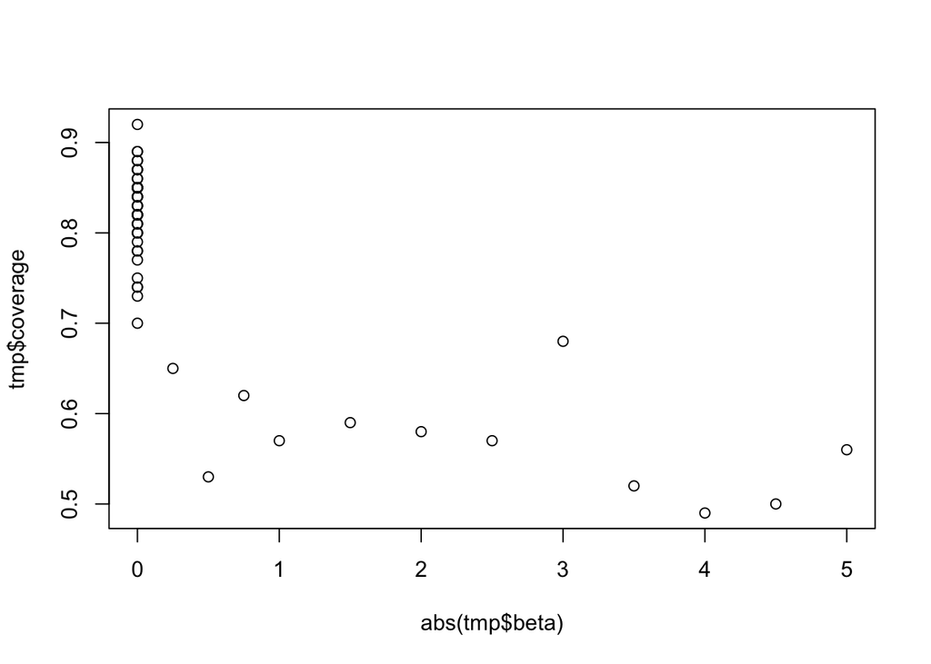

```r
tmp <- data.frame(coverage = apply(res$indiv_cov, 2, mean) , beta = res$truth)
plot(abs(tmp$beta), tmp$coverage)
```